# CONCEPT STROKE: Analytical pipeline

Author

Data Science for Health Services and Policy Research (IACS)

## Introduction

### Definition

CONCEPT STROKE is a study analysing the acute care received by patients with acute ischaemic stroke where the aim is to show the relevance of care pathways on outcomes (traces/trajectories) and efficiency of stroke care.

- Participating regions: Aragón, País Vasco, Cataluña, Navarra and Valencia.

It is a two-stage design:

1- Cross-sectional data mining design

2- Quasi-experimental design comparing interventions in acute ischaemic stroke.

The Main endpoints are:

1- In the first stage, the pathway of care as it occurs in real life and the propensity of a patient to follow a specific pathway (trace).

2- In the second stage, the survival of patients 30 days and 6 months after the admission to an emergency room

### Cohort

The cohort is defined as patients admitted to hospital due to acute ischaemic stroke.

- Inclusion criteria: Patients aged 18 years or older admitted to the emergency department (or with an unplanned hospital admission) with a principal diagnosis of acute ischaemic stroke during the study period.
- Exclusion criteria: Patients aged 17 years or younger; Patients with a diagnosis of acute haemorrhagic stroke or with other non-specific stroke diagnoses.
- Study period: 01-01-2010 to most recent data.

### Analysis plan

A- Process mining to discover and compare actual care pathways with the theoretical pathway and with those present in the participating regions.

B- Survival analysis to provide prediction of health outcomes within each pathway.

C- Hierarchical generalised additive hierarchical modelling to compare the effectiveness of interventions within pathways.

D- Economic evaluation to measure economic impact and efficiency.

## Running code

### Descriptive analysis

To study the observed data, we performed a small exploratory analysis of the data. First, we must convert our DataFrame data to an Event Log object. However, one of the drawbacks we may have when creating our Event Log is the granularity of the dates, as hospital dates are usually accurate to the day while emergency dates are usually accurate to the second. Therefore, we need to generate a function to check that they are correct and see if any of them do not make medical sense. We may find errors such as, for example, having emergency and hospital dates on the same day and, as they have different granularity, automatically the hospital date is ordered first or, for example, emergency discharge date is prior to the admission date, among others.

As part of the exploratory analysis it is interesting to know how many different pathways appear and the frequency of each one. This allows us to know what percentage of the pathways are among the most frequent pathways and which pathways are isolated cases.

### A- Process Mining

For process mining we created several functions depending on the part of the process mining study, which can be divided into:

- Process discovery
- Conformance checking
- Decision mining
- Prediction

#### Process discovery

Process discovery attempts to find a suitable process model that describes the order of events/activities that are executed during the execution of a process.

The next step after the descriptive analysis was to build a Petri net to discover the process. For this, there are different algorithms: alpha mining, inductive mining or heuristic mining.

However, another type of graph that can be built is the Directly Follows Graph (DFG), which is a graph that, although it can be part of the discovery process, serves as a descriptive analysis as it shows all possible pathways present in the data.

To reduce the high dimensionality, one option is to filter the traces to keep only the k most frequent traces. In this case we filtered by the k=10 most frequent traces.

#### Conformance checking

Conformance checking is a technique for comparing a process model with an event record of the same process. However, as a first approximation, we made a comparison between the most frequent pathways and the one we established as theoretical by Jaccard similarity without taking into account the order, so that the quotient between is calculated:

- Numerator: number of activities that coincide between each of these pathways with the standard.
- Denominator: number of activities of the union between each one of these pathways with the regulation.

#### Decision mining

Decision mining allows us to know what are the main characteristics of patients that make them follow a certain path. To do this, patient characteristics are added to the Event log. Petri net is created using the inductive algorithm and the decision points of the net are observed. We see the importance of the characteristics at one decision point. It is like a decision tree at the decision point. This step may be helpful to know which variables are of importance for input into the prediction model in the next section.

#### Prediction

To predict which pathway a given patient should follow based on his or her characteristics, we have used the *bupaR* library, which makes use of a transformer model to predict the pathway as a sequence of activities. Thus, an Event log with features and a transformer model is used to predict the next activity.

### B- Survival analysis

We carried out a survival analysis with the 10 most frequent traces, constructing a Kaplan-Meier curve for each of them for comparison. Subsequently, a COX model was performed to compare these pathways and observe the Hazard Ratio (HR) of each pathway compared to the rest.

### C- GAMM model

Generalised additive mixed model (GAMM) with smoothed interaction between period (month) and intervention (reperfusion) and trace as an aggregation factor at the second level. Then, generate two new variables:

- Duration of the trace for each patient.
- Period in which the intervention took place.

## Results

These results have been carried out with synthetic data previously generated according to the data model.

### Descriptive analysis

First, we imported and converted our DataFrame to an Event Log and check dates.

```
There are 92 errors in emergency dates, if there are errors they may be dates outside the limits or there may be dates without having entered the emergency
There are 0 errors in hospital dates, if there are errors they may be dates outside the limits or there are dates without having entered the hospital
There are 2 errors in hospital dates with emergency dates, the hospital admission date is between the emergency admission and discharge date (included).
```

As a descriptive measure of the data, a bar plot with the number of distinct traces and their frequency.

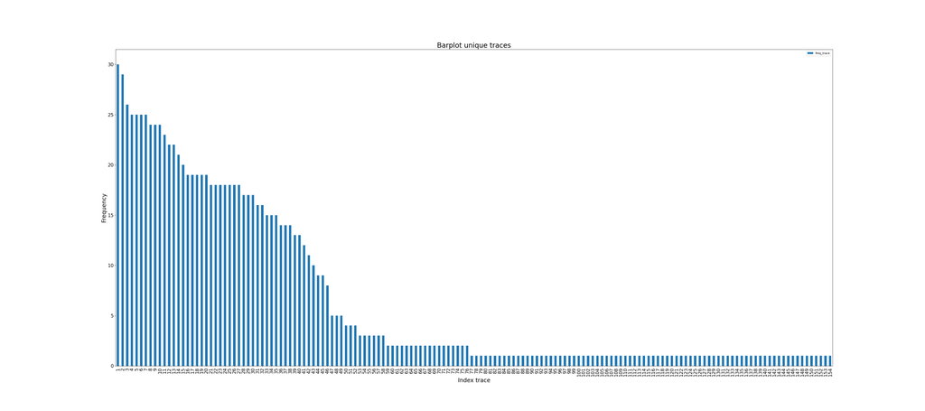

Figure 1: Bar plot with the number of distinct traces and their frequency

### A- Process mining

#### Process discovery

Directly follows graph with all event log pathways:

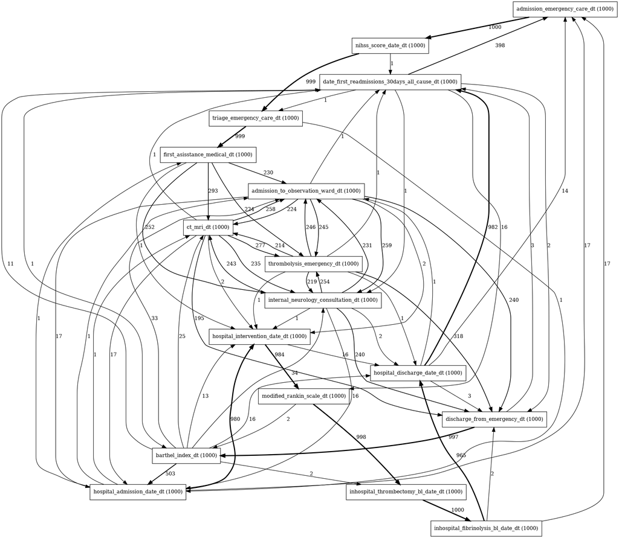

Figure 2: Directly follows graph with all event log pathways

This looks like spaghetti graph, so, in order to reduce the high dimensionality, we filtered the traces to keep only the k (k=10) most frequent traces:

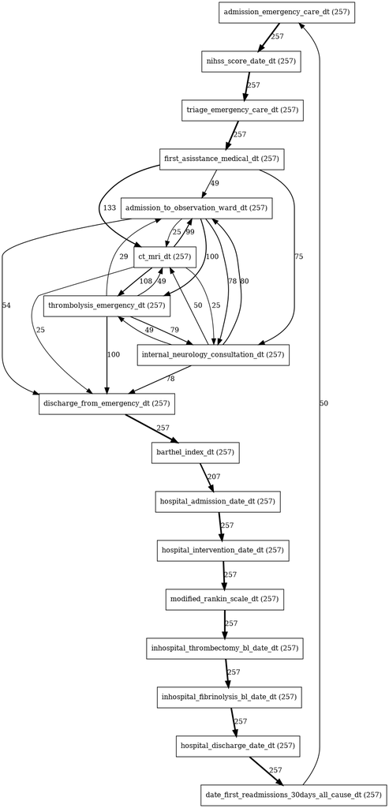

Figure 3: Directly follows graph with most frequent pathways

Alpha miner with only filtered traces:

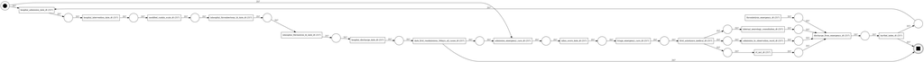

Figure 4: Alpha miner with only filtered traces

Inductive miner with only filtered traces:

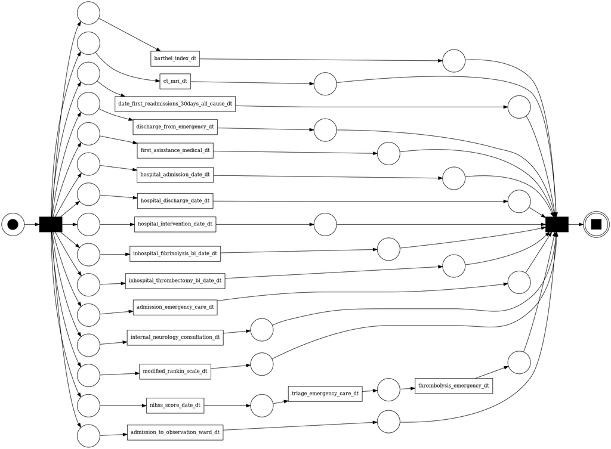

Figure 5: Inductive miner with only filtered traces

Heuristic miner with only filtered traces:

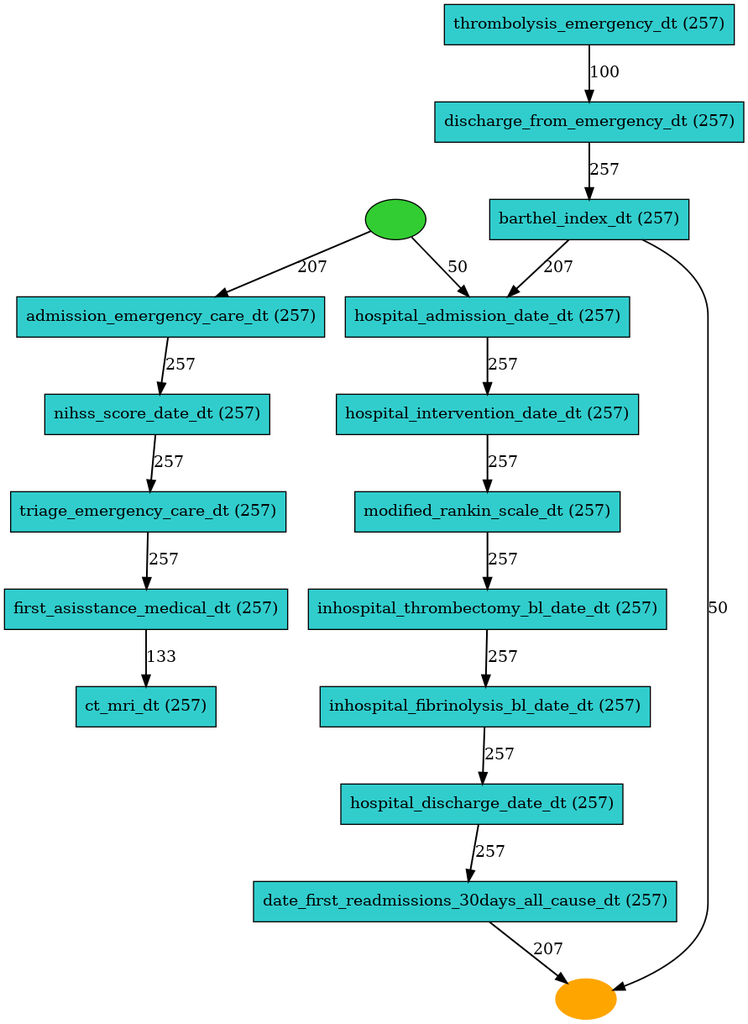

Figure 6: Heuristic miner with only filtered traces

#### Conformance checking

Comparison of the 10 most frequent traces with the theoretical one, using Jaccard’s similarity method without taking into account the order:

The theorical trace is:

```
admission_emergency_care_dt,triage_emergency_care_dt,first_asisstance_medical_dt,internal_neurology_consultation_dt,ct_mri_dt,admission_to_observation_ward_dt,thrombolysis_emergency_dtdischarge_from_emergency_dt
```

The Jaccard’s similarity measured is:

```
0.33
0.33
0.33
0.33
0.33
0.33
0.33
0.33
0.33
0.33
```

#### Decision mining

First we created a petri net with the inductive algorithm that will allow us to know the different decision points, we can see that the two images below are the same petri net, showing in the first one the decision points and in the second one the activities (transitions). In this section, in order to create a petri net with decision points, it was necessary to delete records from the event log.

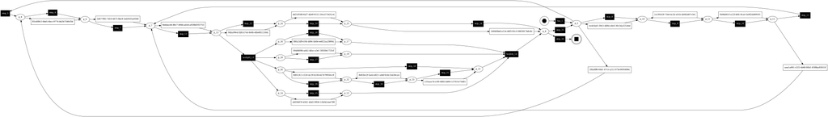

Figure 7: Petri net wiht points for decision mining

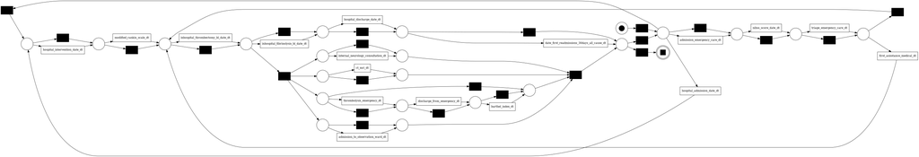

Figure 8: Petri net with activities for decision mining

After that we created the petri net, we were able to see the importance of the features at decision/s point/s.

In this case, the point/s is/are:

```
The decision point for fibrinolysis in hospital is: p_13
```

```
The decision point for thrombectomy in hospital is: p_7
```

```
The decision point for thrombolysis in emergency is: p_20
```

**Decision point 1**

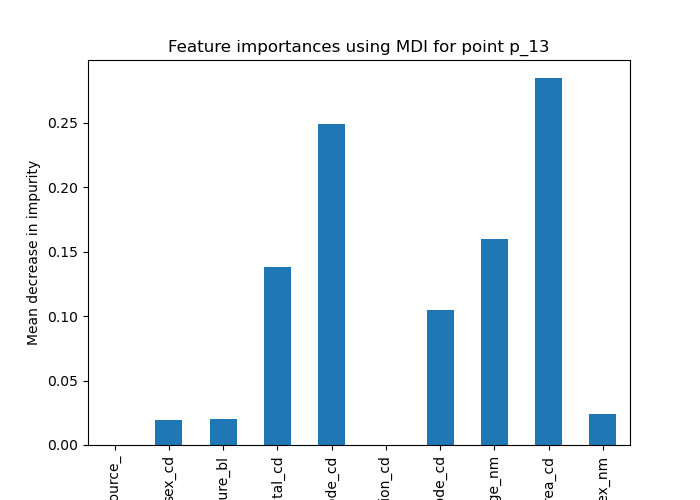

**Decision point 2**

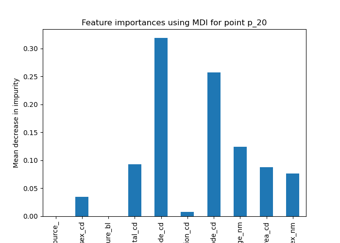

**Decision point 3**

[figure not shown]

#### Prediction

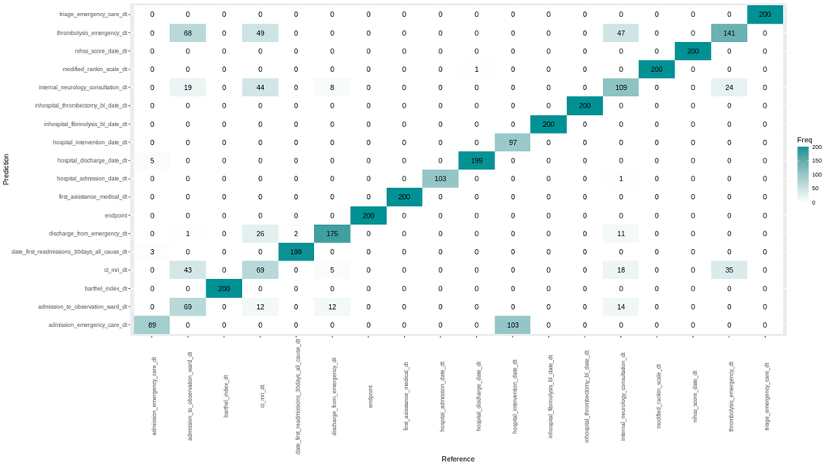

Figure 9: Confusion matrix for predictions

### B- Survival analysis

The kaplan-meier curves for the 10 most common pathways and the cox model summary are shown.

```
<lifelines.CoxPHFitter: fitted with 257 total observations, 0 right-censored observations>
             duration col = 'survival_in_days'
                event col = 'status'
                penalizer = 0.1
                 l1 ratio = 0.0
      baseline estimation = breslow
   number of observations = 257
number of events observed = 257
   partial log-likelihood = -1165.81
         time fit was run = 2023-10-19 10:20:12 UTC

---
            coef  exp(coef)   se(coef)   coef lower 95%   coef upper 95%  exp(coef) lower 95%  exp(coef) upper 95%
covariate
trace_1    -0.05       0.95       0.27            -0.57             0.47                 0.57                 1.60
trace_2    -0.08       0.92       0.27            -0.61             0.44                 0.55                 1.55
trace_3     0.20       1.22       0.28            -0.34             0.74                 0.71                 2.09
trace_4    -0.02       0.98       0.28            -0.56             0.52                 0.57                 1.69
trace_5     0.22       1.25       0.28            -0.32             0.77                 0.72                 2.15
trace_6    -0.18       0.84       0.28            -0.72             0.36                 0.49                 1.44
trace_7     0.46       1.58       0.28            -0.09             1.01                 0.91                 2.74
trace_8     0.11       1.12       0.28            -0.44             0.66                 0.65                 1.94
trace_9    -0.39       0.68       0.28            -0.94             0.16                 0.39                 1.18
trace_10   -0.28       0.76       0.28            -0.83             0.27                 0.44                 1.32

            cmp to     z    p   -log2(p)
covariate
trace_1       0.00 -0.19 0.85       0.24
trace_2       0.00 -0.31 0.76       0.40
trace_3       0.00  0.71 0.48       1.07
trace_4       0.00 -0.07 0.95       0.08
trace_5       0.00  0.80 0.42       1.24
trace_6       0.00 -0.64 0.52       0.95
trace_7       0.00  1.64 0.10       3.31
trace_8       0.00  0.40 0.69       0.53
trace_9       0.00 -1.38 0.17       2.58
trace_10      0.00 -0.98 0.32       1.62
---
Concordance = 0.56
Partial AIC = 2351.61
log-likelihood ratio test = 14.00 on 10 df
-log2(p) of ll-ratio test = 2.53
```

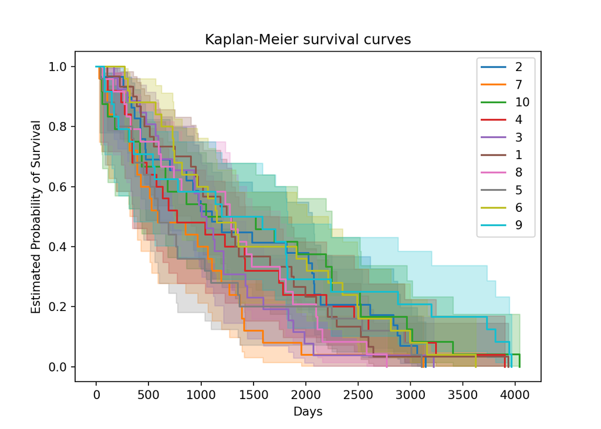

Survival analysis

### C- GAMM model

The summary and plots for the gamm model are:

```
Family: gaussian
Link function: identity

Formula:
exitus_bl ~ thrombolysis_emergency_bl + s(period, by = rank_trace,
    k = 20) + s(age_nm, k = 20) + s(period, by = thrombolysis_emergency_bl,
    k = 20) + s(dur_trace)

Parametric coefficients:
                          Estimate Std. Error t value Pr(>|t|)
(Intercept)                0.47301    0.06894   6.861 5.69e-11 ***
thrombolysis_emergency_bl -0.48872    0.35638  -1.371    0.172
---
Signif. codes:  0 '***' 0.001 '**' 0.01 '*' 0.05 '.' 0.1 ' ' 1

Approximate significance of smooth terms:
                                      edf Ref.df     F p-value
s(period):rank_trace                2.615  2.999 1.582  0.1986
s(age_nm)                           1.000  1.000 2.766  0.0976 .
s(period):thrombolysis_emergency_bl 4.077  4.969 1.248  0.2594
s(dur_trace)                        5.940  7.108 2.586  0.0129 *
---
Signif. codes:  0 '***' 0.001 '**' 0.01 '*' 0.05 '.' 0.1 ' ' 1

Rank: 69/70
R-sq.(adj) =  0.0883   Deviance explained = 13.9%
GCV = 0.2427  Scale est. = 0.22841   n = 257
```

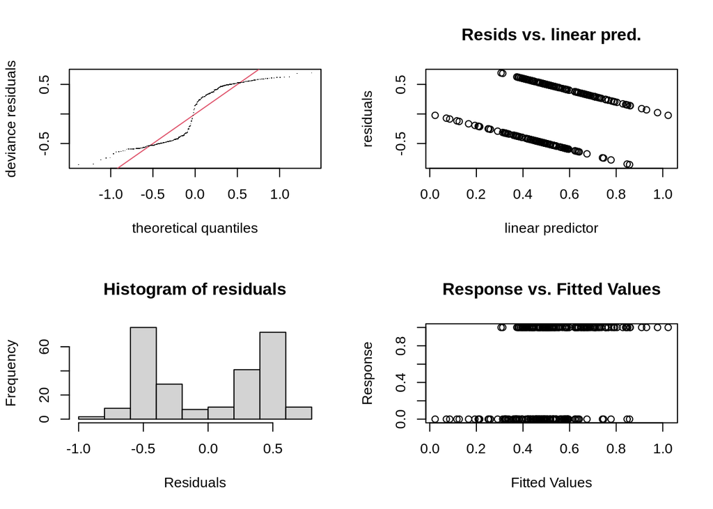

```
Method: GCV   Optimizer: magic
Smoothing parameter selection converged after 11 iterations.
The RMS GCV score gradient at convergence was 4.488486e-08 .
The Hessian was positive definite.
Model rank =  69 / 70

Basis dimension (k) checking results. Low p-value (k-index<1) may
indicate that k is too low, especially if edf is close to k'.

                                       k'   edf k-index p-value
s(period):rank_trace                20.00  2.62    0.98    0.28
s(age_nm)                           19.00  1.00    1.09    0.93
s(period):thrombolysis_emergency_bl 20.00  4.08    0.98    0.34
s(dur_trace)                         9.00  5.94    0.99    0.40
```